# 多元统计的图方法

王宁宁 广州医科大学统计学系

## **准备工作**

```r
# getwd()
# rm(list = ls(all = TRUE))
dir<-"D:\\mywork\\study_R\\multivariate ana" #工作文件夹，如不一致请修改
dirdata<-"D:/mywork/study_R/multivariate ana/data/" #数据存放的文件夹，如不一致请修改
setwd(dir)
# pkg<-search();pkg
# length(pkg)-1
# i=1
# while(i < length(pkg)-1) {
#   detach(pkg[2],character.only = TRUE)
#   i=i+1
#   }
```

### **加载将要用到的包**：

```r
library("MVA") #调用MVA包，要用到几个绘图函数
set.seed(28085)# 设定随机数种子，保证取得随机数一致
library("lattice")# R中使用最多的绘图包，下面是一些绘图参数的设定，初学者无需理会
```

### **加载将要用到的数据**

数据描述：

USairpollution： 1970年美国41个城市的空气污染的数据，关于各变量的详细的数据描述看[这里](http://finzi.psych.upenn.edu/library/HSAUR2/html/USairpollution.html)或[这里](http://www.stats4stem.org/r-usairpollution-data.html)。

```r
# measure <- read.table(file=paste(dirdata,"measure.txt",sep=""))
# head(measure)
data("USairpollution", package = "HSAUR2")
head(USairpollution)
```

```
##             SO2 temp manu popul wind precip predays
## Albany       46 47.6   44   116  8.8  33.36     135
## Albuquerque  11 56.8   46   244  8.9   7.77      58
## Atlanta      24 61.5  368   497  9.1  48.34     115
## Baltimore    47 55.0  625   905  9.6  41.31     111
## Buffalo      11 47.1  391   463 12.4  36.11     166
## Charleston   31 55.2   35    71  6.5  40.75     148
```

## 二元连续变量的散点图

> 散点图是用来表述二元连续变量的最基本方式。

下图是USairpollution数据集中，manu（人数超过20个工人的生产商的数量）和 cpopul（各个城市的人口数，单位：千）

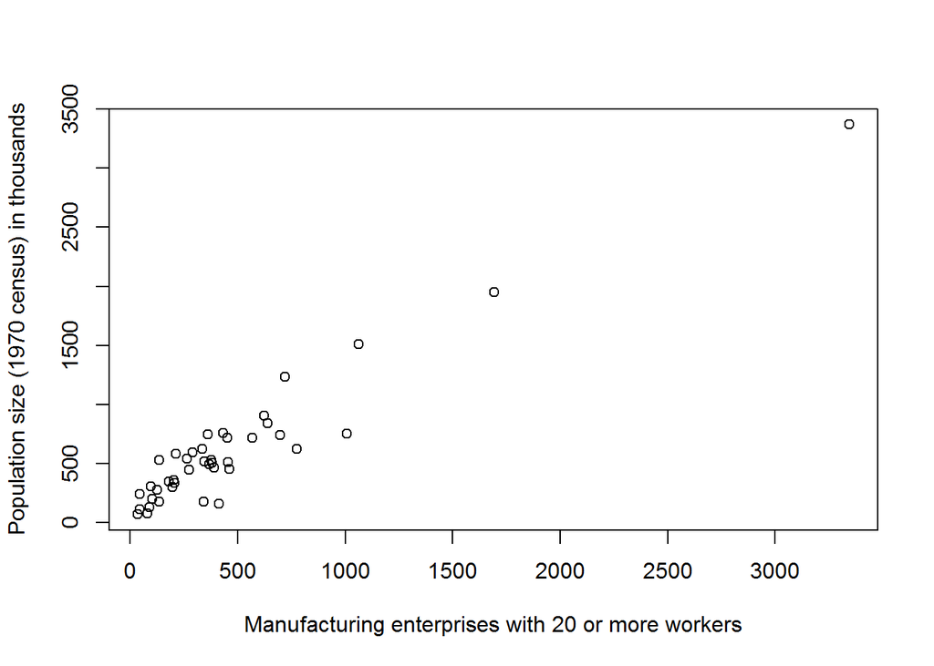

```r
mlab <- "Manufacturing enterprises with 20 or more workers"
plab <- "Population size (1970 census) in thousands"
plot(popul ~ manu, data = USairpollution,
     xlab = mlab, ylab = plab)
```

**思考**：从上面的散点图可以得到什么信息？

**练习**：请确定有可能的离群点是哪几个城市？

```r
USairpollution[which(USairpollution$manu>1000),]
```

```
##              SO2 temp manu popul wind precip predays
## Chicago      110 50.6 3344  3369 10.4  34.44     122
## Cleveland     65 49.7 1007   751 10.9  34.99     155
## Detroit       35 49.9 1064  1513 10.1  30.96     129
## Philadelphia  69 54.6 1692  1950  9.6  39.93     115
```

为了在易于确认这几个点，我们在图中加上刻度，这里要用到rug，请自行查阅’help(rug)’的用法

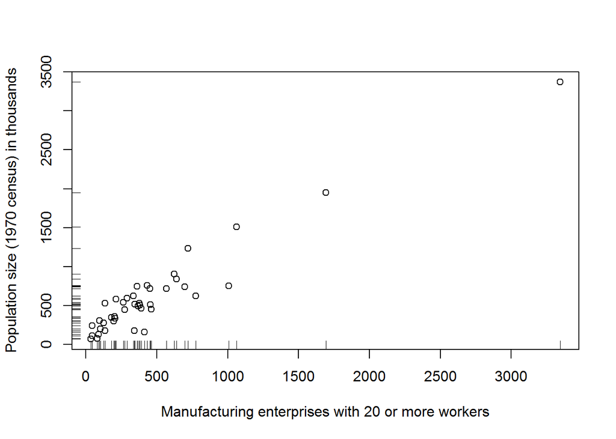

```r
plot(popul ~ manu, data = USairpollution,
     xlab = mlab, ylab = plab)
rug(USairpollution$manu, side = 1)
rug(USairpollution$popul, side = 2)
```

进一步，我们可以在图中把这几个点标注出来：

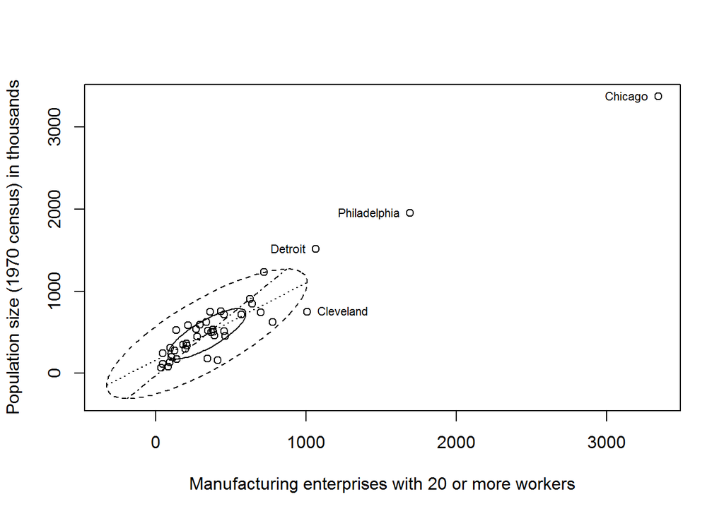

```r
outcity <- match(lab <- c("Chicago", "Detroit",
    "Cleveland", "Philadelphia"), rownames(USairpollution))
x <- USairpollution[, c("manu", "popul")]
bvbox(x, mtitle = "", xlab = mlab, ylab = plab)
text(x$manu[outcity], x$popul[outcity], labels = lab,
     cex = 0.7, pos = c(2, 2, 4, 2, 2))
```

算一下这两个变量的相关系数

```r
with(USairpollution, cor(manu, popul))
```

```
## [1] 0.9552693
```

```r
outcity <- match(c("Chicago", "Detroit",
                   "Cleveland", "Philadelphia"),
                 rownames(USairpollution))
with(USairpollution, cor(manu[-outcity], popul[-outcity]))
```

```
## [1] 0.7955549
```

可见，除去几个异常值，相关系数降低很多

## 卡方图（chi-plot）

卡方图是Fisher 和 Switzer 在1985年提出的，用来判断连续变量的相关性。这种方法在判断局部相关或尾部相关时使用较多。下面我们用MVA包里的chiplot来画 manu和 popul 的卡方图：

如果变量是独立的，那么chi-plot是均匀分布在-1到1之间的。如果chi-plot有 聚集倾向时，则不独立。

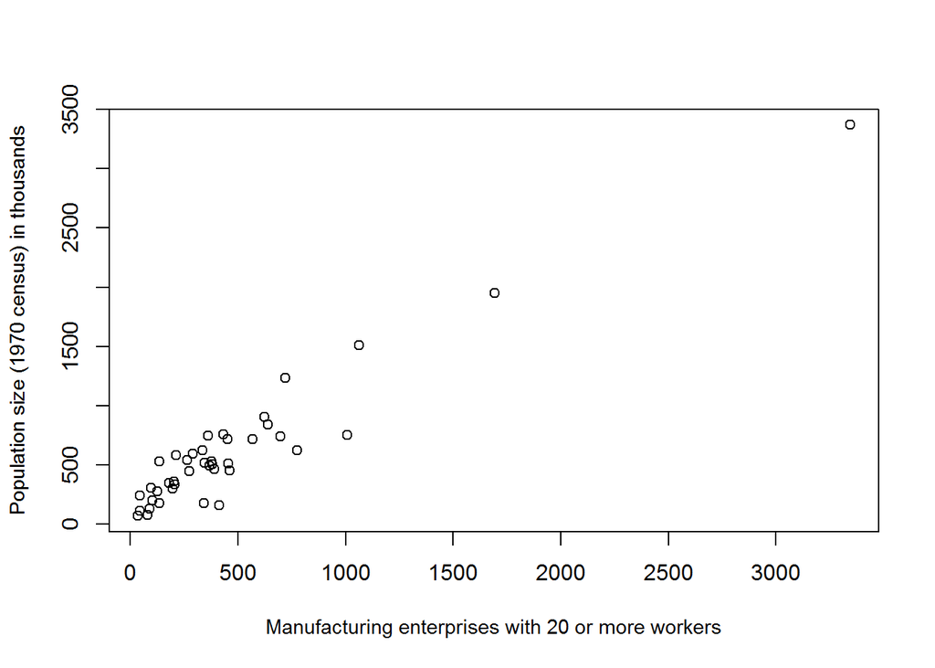

```r
with(USairpollution, plot(manu, popul,xlab = mlab, ylab = plab, cex.lab = 0.9))
```

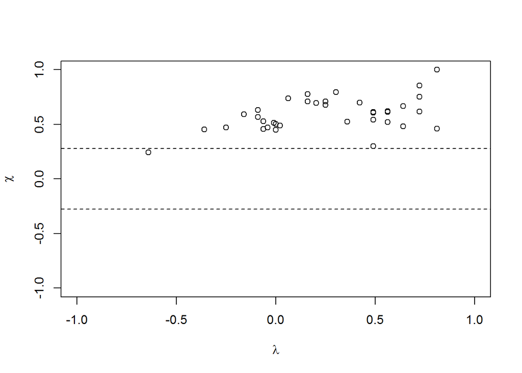

```r
with(USairpollution, chiplot(manu, popul))
```

## 气泡图（bubble plot）

当变量多于两个时，以上的方法就不再适用。可以考虑气泡图：

下面是关于美国空气污染数据集里，三个变量的关系，temp（年平均温度）、wind（年平均风速）、SO2（空气中二氧化硫的含量）的气泡图，气泡的大小标志二氧化硫含量的多少。

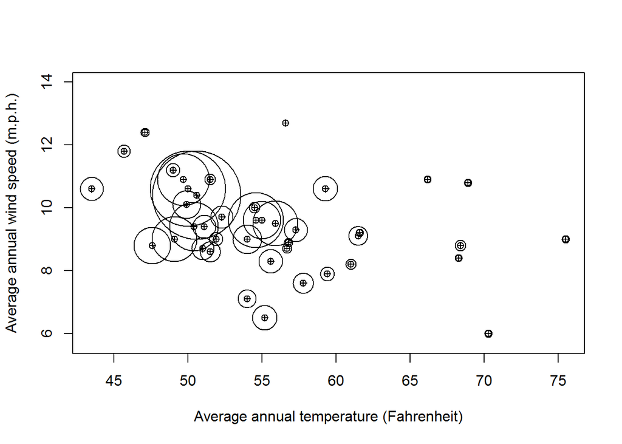

```r
ylim <- with(USairpollution, range(wind)) * c(0.95, 1.1)
plot(wind ~ temp, data = USairpollution,
     xlab = "Average annual temperature (Fahrenheit)",
     ylab = "Average annual wind speed (m.p.h.)", pch = 10,
     ylim = ylim)
with(USairpollution, symbols(temp, wind, circles = SO2,
                             inches = 0.5, add = TRUE))
```

## 星形图

也可以用星形图表示更多的变量：

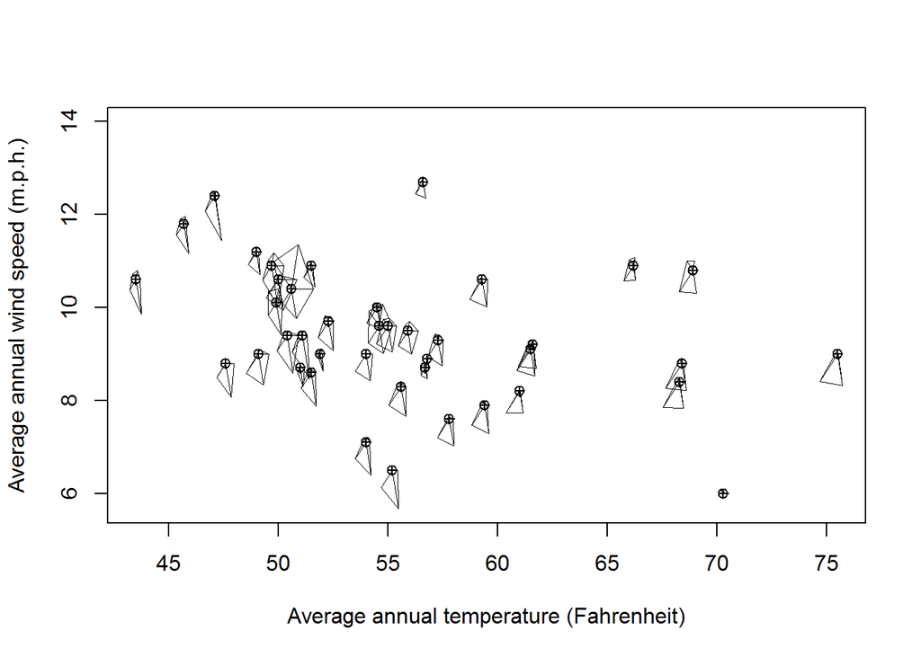

```r
plot(wind ~ temp, data = USairpollution,
     xlab = "Average annual temperature (Fahrenheit)",
     ylab = "Average annual wind speed (m.p.h.)", pch = 10,
     ylim = ylim)
with(USairpollution,
    stars(USairpollution[,-c(2,5)], locations = cbind(temp, wind),
          labels = NULL, add = TRUE, cex = 0.5))
```

每个城市的星形图：

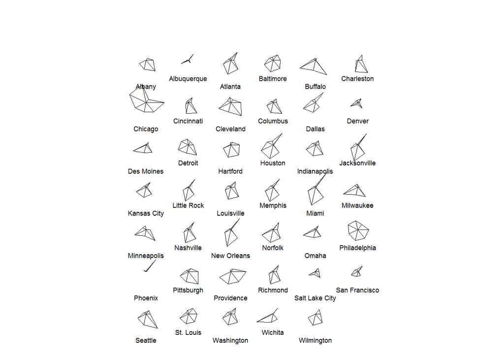

```r
stars(USairpollution, cex = 0.55)
```

## 散点图矩阵

两两变量的相关图：

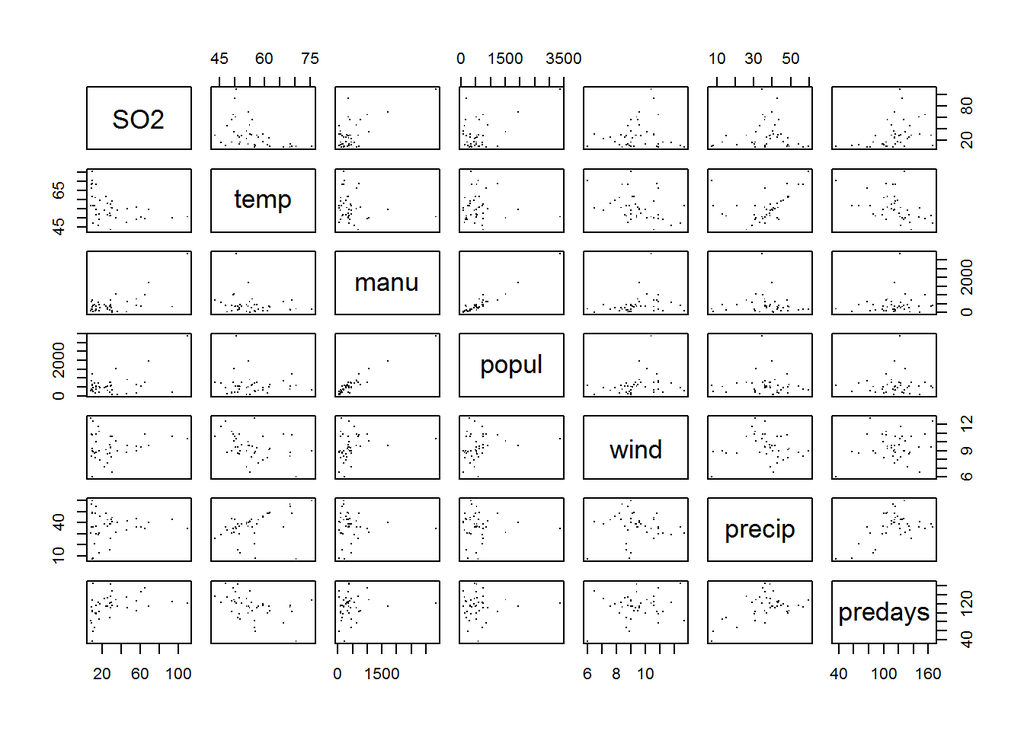

```r
pairs(USairpollution, pch = ".", cex = 1.5)
```

每个相关图加上回归直线：

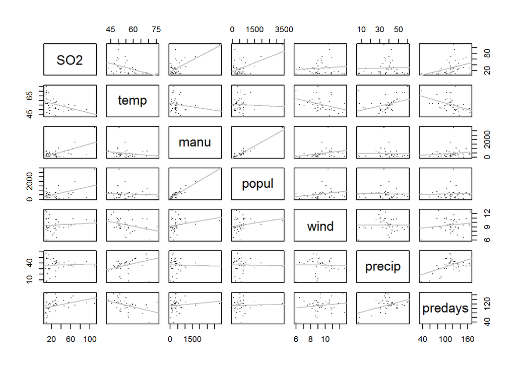

```r
pairs(USairpollution,
      panel = function (x, y, ...) {
          points(x, y, ...)
          abline(lm(y ~ x), col = "grey")
      }, pch = ".", cex = 1.5)
```

```r
round(cor(USairpollution), 4)
```

```
##             SO2    temp    manu   popul    wind  precip predays
## SO2      1.0000 -0.4336  0.6448  0.4938  0.0947  0.0543  0.3696
## temp    -0.4336  1.0000 -0.1900 -0.0627 -0.3497  0.3863 -0.4302
## manu     0.6448 -0.1900  1.0000  0.9553  0.2379 -0.0324  0.1318
## popul    0.4938 -0.0627  0.9553  1.0000  0.2126 -0.0261  0.0421
## wind     0.0947 -0.3497  0.2379  0.2126  1.0000 -0.0130  0.1641
## precip   0.0543  0.3863 -0.0324 -0.0261 -0.0130  1.0000  0.4961
## predays  0.3696 -0.4302  0.1318  0.0421  0.1641  0.4961  1.0000
```